# Challenge_4: Intro to Visulization: Univariate and Multivariate Graphs

weekly_challenges

challenge_4

Author

Bhavani Priya

Published

October 18, 2023

**Make sure you change the author’s name in the above YAML header.**

## Setup

If you have not installed the following packages, please install them before loading them.

```r
library(tidyverse)
library(readxl)
library(haven) #for loading other datafiles (SAS, STATA, SPSS, etc.)
library(stringr) # if you have not installed this package, please install it.
library(ggplot2) # if you have not installed this package, please install it.
knitr::opts_chunk$set(echo = TRUE, warning=FALSE, message=FALSE)
```

## Challenge Overview

In this challenge, we will practice with the data we worked on in the previous challenges and the data you choose to do some simple data visualizations using the `ggplot2` package.

There will be coding components and writing components. Please read the instructions for each part and complete your challenges.

## Datasets

- Part 1 the ESS_Polity Data (created in Challenge#3) ⭐⭐
- Part 2: the Australia Data⭐⭐
- Part 3: see Part 3. Practice plotting with a dataset of your choice (25% of the total grade). For online platforms of free data, see Appendix: sources for data to be used in Part 3.

Find the `_data` folder, then read the datasets using the correct R command.

## Part 1. Univariate and Multivariate Graphs (45% of the total grade)

We have been working with these two data in the previous three challenges. Suppose we have a research project that studies European citizens’ social behaviors and public opinions, and we are interested in how the countries that respondents live in influence their behavior and opinion. In this challenge, let’s work with the combined dataset *ESS_Polity* and create some visualizations.

1. **Read the combined data you created last time. (2.5%)**

```r
  #reading ESS_Polity data using read_csv
  ESS_Polity <- read_csv("./ESS_Polity.csv")

  #sanity check
  head(ESS_Polity)
```

| idno | Year | male | age | edu | income_10 | eth_major | Code | vote | Country | p5 | cyear | ccode | scode | flag | fragment | democ | autoc |
| --- | --- | --- | --- | --- | --- | --- | --- | --- | --- | --- | --- | --- | --- | --- | --- | --- | --- |
| 15906 | 2010 | 0 | 14 | 1 | 2 | 1 | GR | 3 | Greece | 0 | 3502010 | 350 | GRC | 0 | 0 | 10 | 0 |
| 21168 | 2010 | 0 | 14 | 1 | 2 | 1 | IE | 3 | Ireland | 0 | 2052010 | 205 | IRE | 0 | 0 | 10 | 0 |
| 40 | 2010 | 0 | 14 | 1 | 8 | NA | LT | 3 | Lithuania | 0 | 3682010 | 368 | LIT | 0 | 0 | 10 | 0 |
| 2108 | 2010 | 0 | 14 | 1 | NA | 1 | RU | 3 | Russian Federation | NA | NA | NA | NA | NA | NA | NA | NA |
| 519 | 2010 | 0 | 14 | 1 | NA | 1 | IL | 2 | Israel | 0 | 6662010 | 666 | ISR | 0 | 3 | 7 | 1 |
| 2304 | 2010 | 0 | 14 | 1 | NA | 1 | ES | 3 | Spain | 0 | 2302010 | 230 | SPN | 0 | 0 | 10 | 0 |

2. **Suppose we are interested in the central tendencies and distributions of the following variables. At the individual level:** *age, male, edu, income_10,* and *vote*. **At the country level**: *democ*.

   (1) Recode the “vote” column: if the value is 1, recode it as 1; if the value is 2, recode it as 0; if the value is 3, recode it as NA. **Make sure to include a sanity check for the recoded data. (2.5%)**

   ```r
   #sanity check without recoding
   unique(ESS_Polity$vote)
   ```

   ```
   [1]  3  2  1 NA
   ```

   ```r
   #recoding vote column values
   ESS_Polity <- ESS_Polity |>
     mutate(vote = case_when(
       vote == 1 ~ 1,
       vote == 2 ~ 0,
       TRUE ~ na_if(vote, 3)
     ))

   #sanity check after recoding
   head(ESS_Polity)
   ```

   | idno | Year | male | age | edu | income_10 | eth_major | Code | vote | Country | p5 | cyear | ccode | scode | flag | fragment | democ | autoc |
   | --- | --- | --- | --- | --- | --- | --- | --- | --- | --- | --- | --- | --- | --- | --- | --- | --- | --- |
   | 15906 | 2010 | 0 | 14 | 1 | 2 | 1 | GR | NA | Greece | 0 | 3502010 | 350 | GRC | 0 | 0 | 10 | 0 |
   | 21168 | 2010 | 0 | 14 | 1 | 2 | 1 | IE | NA | Ireland | 0 | 2052010 | 205 | IRE | 0 | 0 | 10 | 0 |
   | 40 | 2010 | 0 | 14 | 1 | 8 | NA | LT | NA | Lithuania | 0 | 3682010 | 368 | LIT | 0 | 0 | 10 | 0 |
   | 2108 | 2010 | 0 | 14 | 1 | NA | 1 | RU | NA | Russian Federation | NA | NA | NA | NA | NA | NA | NA | NA |
   | 519 | 2010 | 0 | 14 | 1 | NA | 1 | IL | 0 | Israel | 0 | 6662010 | 666 | ISR | 0 | 3 | 7 | 1 |
   | 2304 | 2010 | 0 | 14 | 1 | NA | 1 | ES | NA | Spain | 0 | 2302010 | 230 | SPN | 0 | 0 | 10 | 0 |

   ```r
   unique(ESS_Polity$vote)
   ```

   ```
   [1] NA  0  1
   ```

   (2) For each of the five variables (*age, edu, income_10,* *vote,* and *democ)*, please choose an appropriate type of univariate graph to plot the central tendencies and distribution of the variables. Explain why you choose this type of graph to present a particular variable (for example: “For example, I use a histogram to plot *age* because it is a continuous numeric variable”). **(25%)**

   **(Note: You should use at least two types of univariate graphs covered in the lecture.)**

   ```r
   summary(ESS_Polity)
   ```

   ```
         idno                Year           male             age
    Min.   :        1   Min.   :2010   Min.   :0.0000   Min.   : 14.00
    1st Qu.:     1433   1st Qu.:2010   1st Qu.:0.0000   1st Qu.: 32.00
    Median :     3673   Median :2010   Median :0.0000   Median : 48.00
    Mean   :  7231685   Mean   :2010   Mean   :0.4535   Mean   : 47.92
    3rd Qu.:   107708   3rd Qu.:2010   3rd Qu.:1.0000   3rd Qu.: 63.00
    Max.   :300003000   Max.   :2010   Max.   :1.0000   Max.   :101.00
                                       NA's   :21       NA's   :137
         edu          income_10        eth_major         Code
    Min.   :1.000   Min.   : 1.000   Min.   :0.000   Length:52458
    1st Qu.:2.000   1st Qu.: 3.000   1st Qu.:1.000   Class :character
    Median :3.000   Median : 5.000   Median :1.000   Mode  :character
    Mean   :2.768   Mean   : 5.049   Mean   :0.937
    3rd Qu.:3.000   3rd Qu.: 7.000   3rd Qu.:1.000
    Max.   :4.000   Max.   :10.000   Max.   :1.000
    NA's   :150     NA's   :12620    NA's   :1310
         vote         Country                p5            cyear
    Min.   :0.000   Length:52458       Min.   :0.000   Min.   :2002010
    1st Qu.:1.000   Class :character   1st Qu.:0.000   1st Qu.:2302010
    Median :1.000   Mode  :character   Median :0.000   Median :3162010
    Mean   :0.763                      Mean   :0.266   Mean   :3164547
    3rd Qu.:1.000                      3rd Qu.:1.000   3rd Qu.:3682010
    Max.   :1.000                      Max.   :1.000   Max.   :6662010
    NA's   :4222                       NA's   :4451    NA's   :4451
        ccode          scode                flag         fragment
    Min.   :200.0   Length:52458       Min.   :0      Min.   :0.000
    1st Qu.:230.0   Class :character   1st Qu.:0      1st Qu.:0.000
    Median :316.0   Mode  :character   Median :0      Median :0.000
    Mean   :316.3                      Mean   :0      Mean   :0.211
    3rd Qu.:368.0                      3rd Qu.:0      3rd Qu.:0.000
    Max.   :666.0                      Max.   :0      Max.   :3.000
    NA's   :4451                       NA's   :4451   NA's   :4451
        democ            autoc
    Min.   : 6.000   Min.   :0.000
    1st Qu.: 9.000   1st Qu.:0.000
    Median :10.000   Median :0.000
    Mean   : 9.453   Mean   :0.048
    3rd Qu.:10.000   3rd Qu.:0.000
    Max.   :10.000   Max.   :1.000
    NA's   :4451     NA's   :4451
   ```

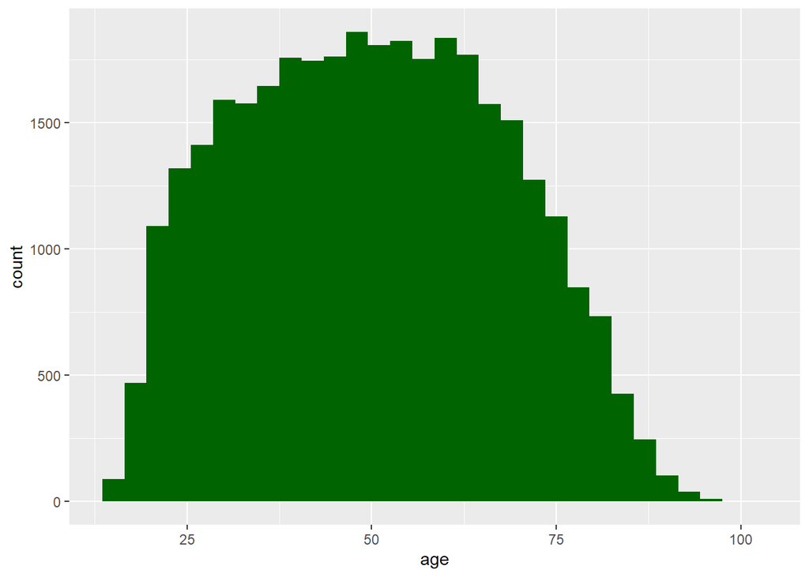

   ```r
   #age variable: histogram.

   #I have used histogram as age variable is a continous variable and histogram automatically removes NA. Binwidth of 3 is chosen to accuartely visualize the distribution of the values
   age_plot <- ggplot(data=na.omit(ESS_Polity) ,aes(x=age)) + geom_histogram(binwidth = 3, fill = "darkgreen", na.rm = TRUE)
   age_plot
   ```

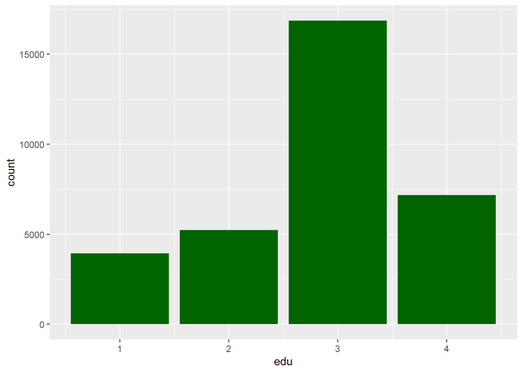

   ```r
   #edu variable: bar.
   #I have used bar graph as education variable is qualitative categorical variable
   edu_plot <- ggplot(data=na.omit(ESS_Polity),aes(x=edu)) + geom_bar(fill ="darkgreen")
   edu_plot
   ```

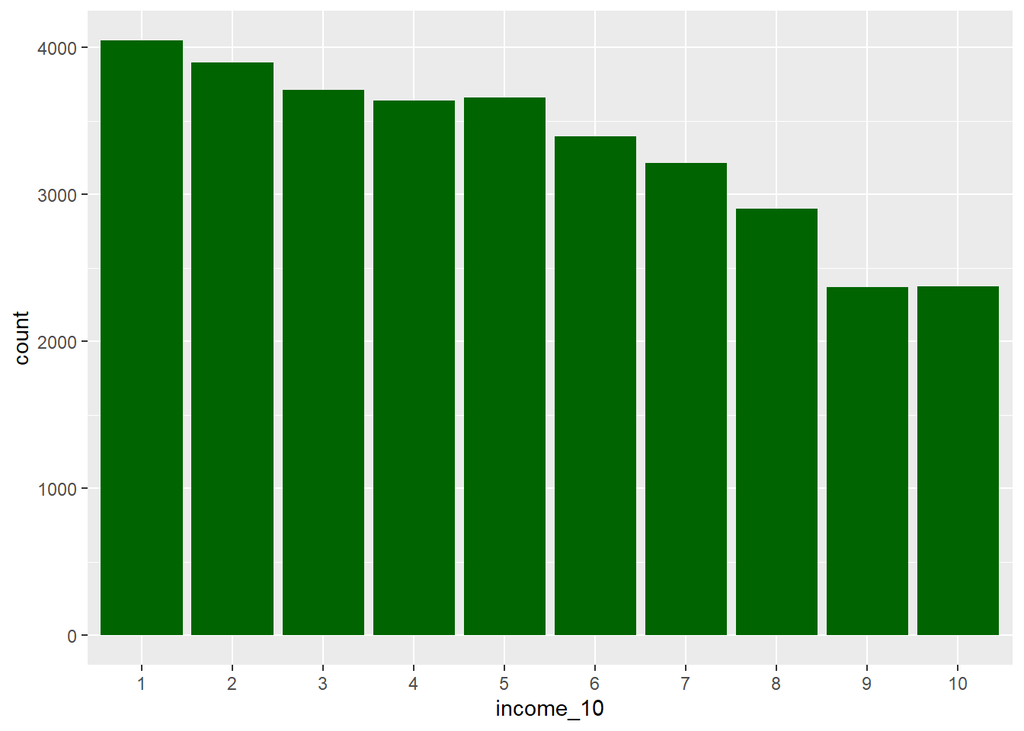

   ```r
   ESS_Polity$income_10 = factor(ESS_Polity$income_10, levels =c(1,2,3,4,5,6,7,8,9,10))
   #income_10 variable : bar,
   #I have used bar graph as income variable is qualitative categorical variable with levels from 1-10
   income_10 <- ggplot(data=na.omit(ESS_Polity),aes(x=income_10)) + geom_bar(fill="darkgreen")
   income_10
   ```

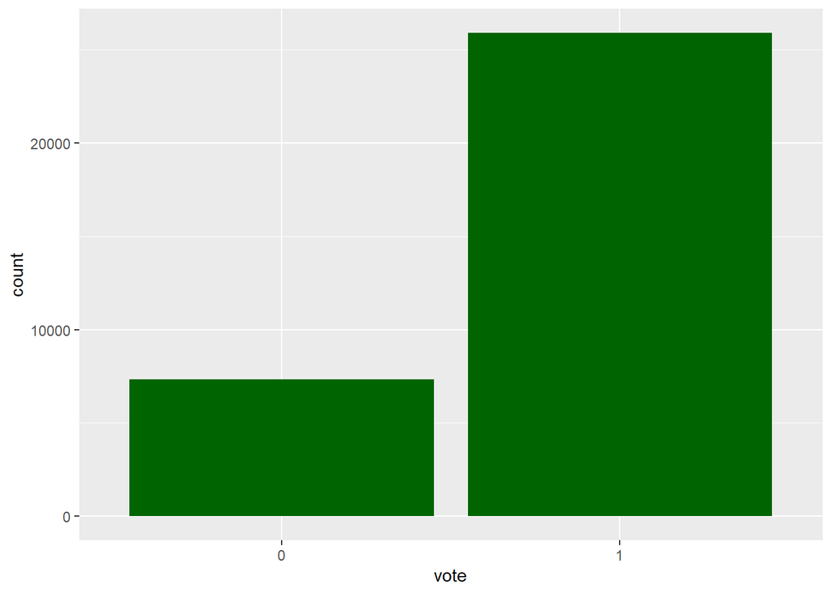

   ```r
   #factoring vote column for visualization
   ESS_Polity$vote <- factor(ESS_Polity$vote)

   #vote variable: bar, I have used bar graph as vote variable is qualitative categorical variable with 0,1 as values
   vote <- ggplot(data = na.omit(ESS_Polity), aes(x=vote)) + geom_bar(fill ="darkgreen")
   vote
   ```

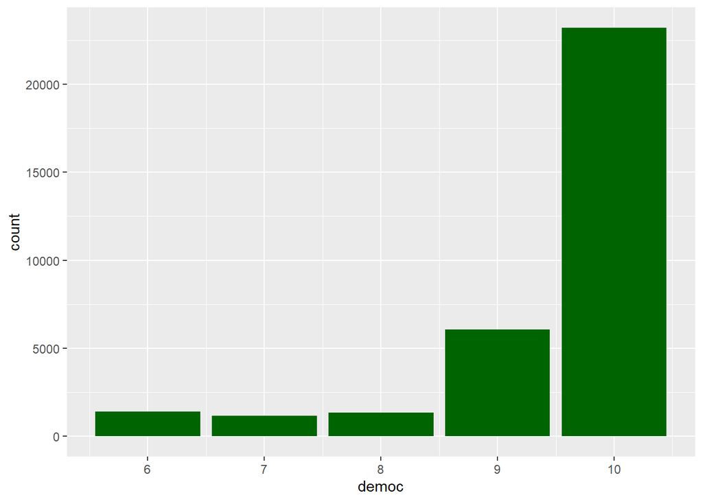

   ```r
   #democ variable: bar, Bar plot as democ variable is categorical qualitative and the values are from 6-10
   democ <- ggplot(data=na.omit(ESS_Polity), aes(x=democ))+geom_bar(fill ="darkgreen")
   democ
   ```

3. **Suppose we want to test two hypotheses on the relationships of two pairs of variables**. **Please use the appropriate type of graphs we learned to visualize these two pairs of variables. Briefly describe the graph you plot, and answer: Does the graph we create from the data support the hypothesis?**

   (1) Hypothesis#1: The more years of education (edu) a person completed, the higher income (income_10) they earn. **(7.5%)**

   Yes, it supports the hypothesis, and we can say that years of education is directly proportional to the income of an individual. However individuals with education level 3 are spread across all the income levels. Individuals with level 4 education earn more than that of level 1 education. By this we can assume that more years education completed higher the income.

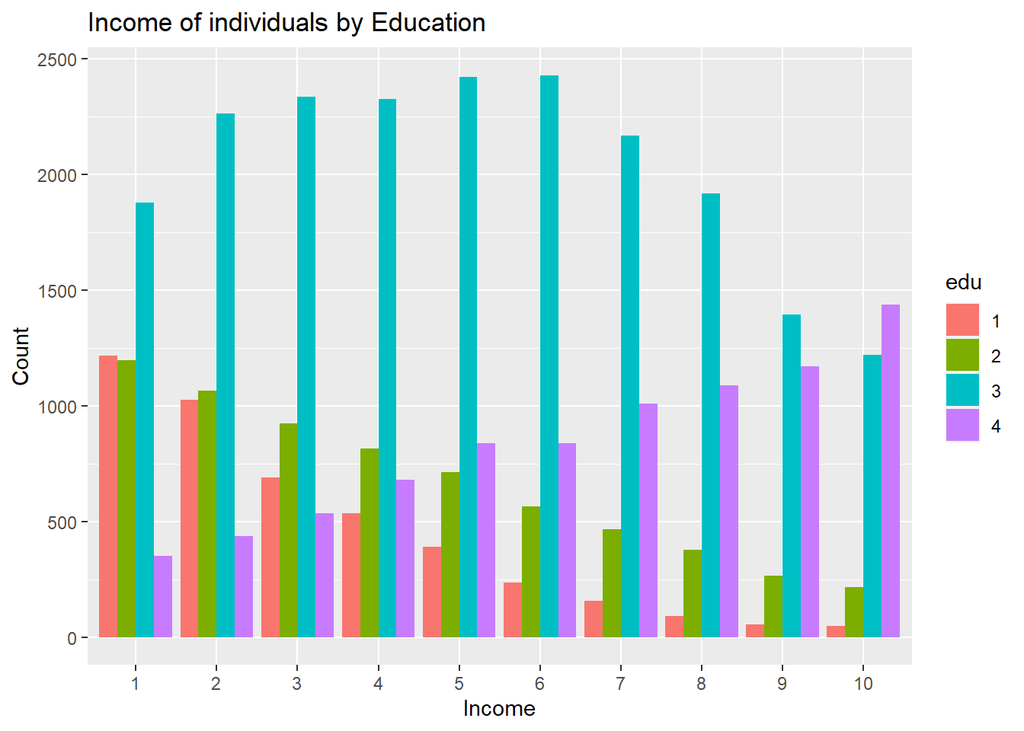

   ```r
     #factoring edu and income_10 columns for analysis
     ESS_Polity$edu <- factor(ESS_Polity$edu,levels=c(1,2,3,4))
     ESS_Polity$income_10 <-factor(ESS_Polity$income_10, levels = c(1,2,3,4,5,6,7,8,9,10))

     #bar plot of edu and income. Bar plot is used as both edu and income are categorical variables
     ESS_Polity |>
   filter(!is.na(edu) & !is.na(income_10)) |>
   group_by(edu)|>
   ggplot( aes(x = income_10, fill = edu)) +
   geom_bar(position = "dodge") +
   labs(title = "Income of individuals by Education",
      x = "Income", y = "Count")
   ```

   (2) Hypothesis#2: There is a gender disparity (male) in voting behavior (vote). (Either men are more likely to vote, or women are more likely to vote). **(7.5%)**

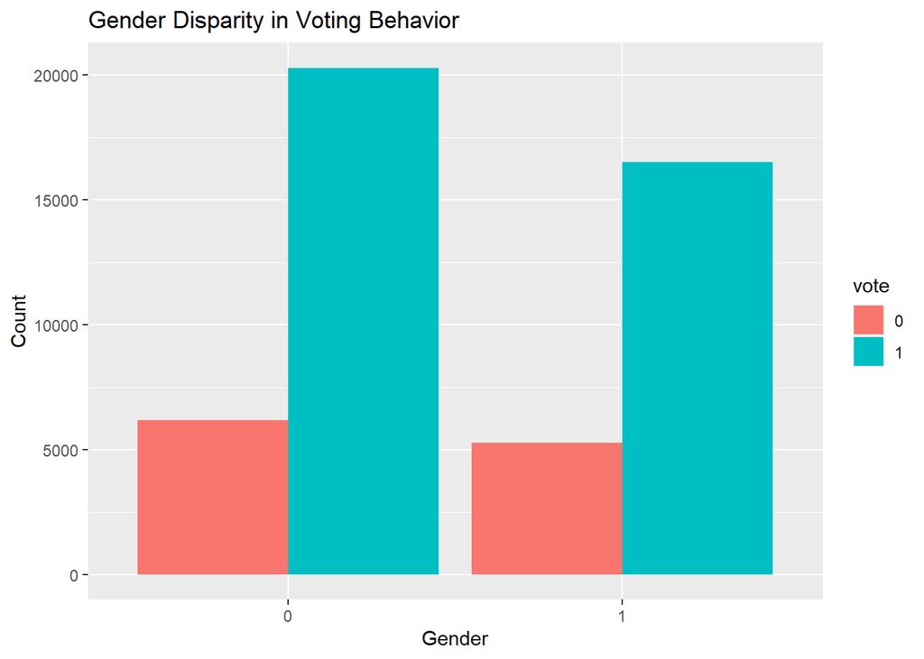

   ```r
     #factoring male and vote columns for analysis
     ESS_Polity$male <-factor(ESS_Polity$male, levels =c(0,1))
     ESS_Polity$vote <- factor(ESS_Polity$vote, levels =c(0,1))

     #bar plot of male and vote
    ESS_Polity |>
      filter(!is.na(male) & !is.na(vote)) |>
      group_by(male) |>
    ggplot(aes(x = male, fill = vote)) +
    geom_bar(position = "dodge") +
    labs(title = "Gender Disparity in Voting Behavior",
      x = "Gender", y = "Count")
   ```

## Part 2. Comparing between Partial and Whole, and among Groups (30% of the total grade)

In this part, we will use the clean version of the Australian public opinion poll on Same-Sex Marriage to generate graphs and plots. **You may need to do the data transformation or mutation needed to help graphing.**

1. Read in data. **(2.5%)**

   ```r
   #reading data using read_csv
   australian_data <- read_csv("australian_data.csv")
   ```

   ```r
   #sanity check
   head(australian_data)
   ```

   | District | Yes | No | Illegible | No Response | Division |
   | --- | --- | --- | --- | --- | --- |
   | Banks | 37736 | 46343 | 247 | 20928 | New South Wales Divisions |
   | Barton | 37153 | 47984 | 226 | 24008 | New South Wales Divisions |
   | Bennelong | 42943 | 43215 | 244 | 19973 | New South Wales Divisions |
   | Berowra | 48471 | 40369 | 212 | 16038 | New South Wales Divisions |
   | Blaxland | 20406 | 57926 | 220 | 25883 | New South Wales Divisions |
   | Bradfield | 53681 | 34927 | 202 | 17261 | New South Wales Divisions |

   ```r
   aus_long <- australian_data |>
     pivot_longer(
   cols = Yes:`No Response`,
   names_to = "Response",
   values_to = "Count"
     )
   head(aus_long)
   ```

   | District | Division | Response | Count |
   | --- | --- | --- | --- |
   | Banks | New South Wales Divisions | Yes | 37736 |
   | Banks | New South Wales Divisions | No | 46343 |
   | Banks | New South Wales Divisions | Illegible | 247 |
   | Banks | New South Wales Divisions | No Response | 20928 |
   | Barton | New South Wales Divisions | Yes | 37153 |
   | Barton | New South Wales Divisions | No | 47984 |

2. Use a barplot to graph the Australian data based on their responses: yes, no, illegible, and no response. The y-axis should be the count of responses, and each response should be represented by one individual bar (so there should be four bars). **(7.5%)**

   (you can use either geom_bar() or geom_col())

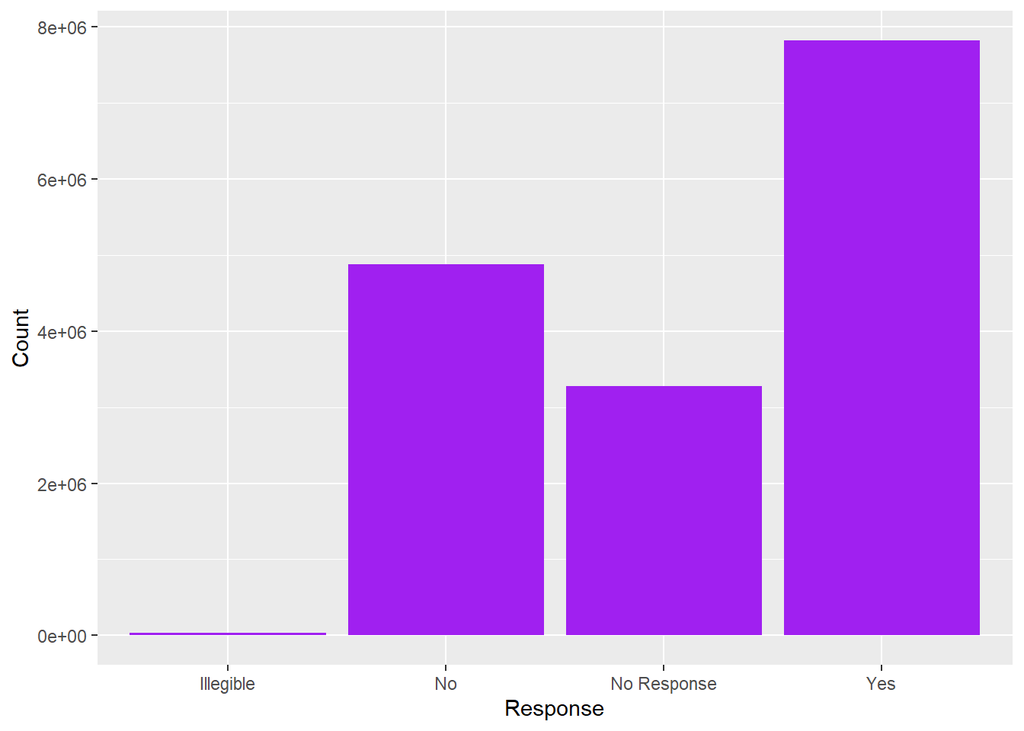

   ```r
    #Plot the barchart for repsonses:

   response_bar<-ggplot(aus_long, aes(x=Response, y=Count))+
     geom_bar(stat="identity",fill="purple")

   response_bar
   ```

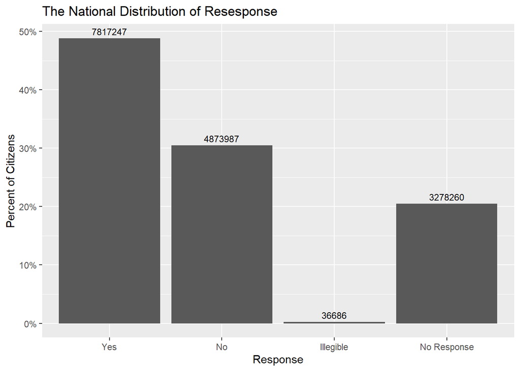

```r
response_bar<-aus_long|>
  mutate(Response = as_factor(Response), #we need to first force R to recognize "Response" as factor
         Response = fct_relevel(Response, "Yes", "No", "Illegible"))|> #then we can use fct_relvel to specify the order of the bars.
  group_by(Response)|>
  summarise(Count = sum(Count))|> # try without specifying group_by and ungroup, what do we got?
  ungroup()|>
  mutate(perc = Count/sum(Count))|>
  ggplot(aes(y=perc, x=Response))+
  geom_col()+
  labs(title = "The National Distribution of Resesponse")+
  scale_y_continuous(name= "Percent of Citizens",
                     label = scales::percent) +
  geom_text(aes(label = Count), size=3, vjust=-.5)

response_bar
```

3. The previous graph only shows the difference in amount. Let’s create a stacked-to-100% barplot to show the proportion of each of the four responses (by % of the total response). **(7.5%)**

   (you can use either geom_bar() or geom_col())

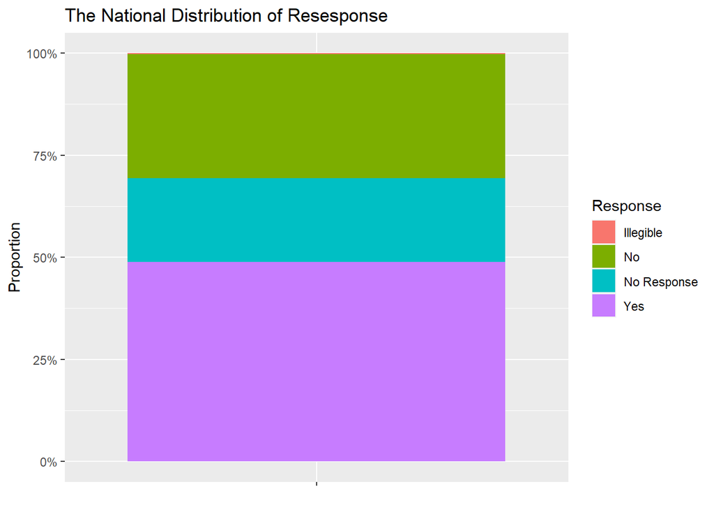

   ```r
      response_stack<-ggplot(aus_long, aes(fill = Response, x = '', y = Count)) +
     geom_bar(stat = "identity", position = "fill") +
     labs(title = "The National Distribution of Resesponse", x = NULL, y = "Proportion") +
     scale_y_continuous(labels = scales::percent_format(scale = 100))

   response_stack
   ```

4. Let’s see if there’s a relationship between Division and Response - that is, are certain divisions more likely to respond one way compared to other divisions? Again, we will use barplot(s) to present the visualization. **(12.5%)**

   (you can use either geom_bar() or geom_col())

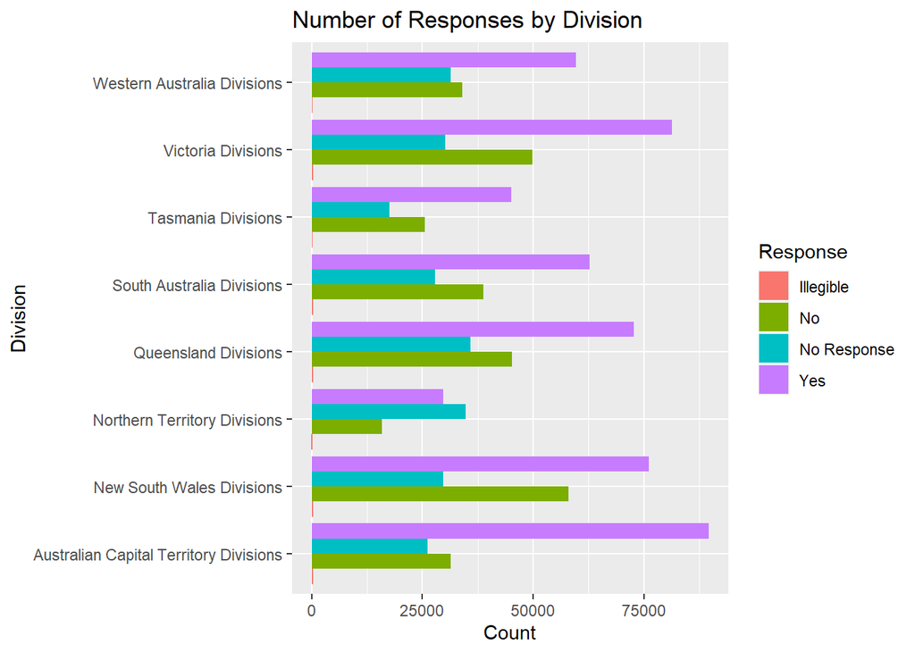

   ```r
   #using bar plot
   aus_long |>
     ggplot(aes(x=Division,y= Count, fill=Response)) +
     geom_bar(position = "dodge",stat = "identity") +
     coord_flip() +
     labs(title = "Number of Responses by Division")
   ```

## Part 3. Practice plotting with a dataset of your choice (25% of the total grade)

In this part, you will choose data of your interests for graphing and plotting. This data can be tidy/ready-to-be-used or raw data that needs cleaning. If the data is very large (for example, more than 20 columns), you should definitely subset the data by selecting less than 10 variables of your interests to avoid taking too much room in your R memory.

1. Include a link to the data page (this page should include the introduction or description and the link to download this dataset). **(2%)** https://www.kaggle.com/datasets/starbucks/starbucks-menu
2. Read the data you choose and briefly answer the following questions. (Optional: you may need to subset, clean, and transform the data if necessary). **(8%)**

   ```r
   #reading data set using read_csv
   starbucks_food <- read_csv("starbucks-menu-nutrition-food.csv")

   #sanity check
   head(starbucks_food)
   ```

   | Item | Calories | Fat (g) | Carb. (g) | Fiber (g) | Protein (g) |
   | --- | --- | --- | --- | --- | --- |
   | Chonga Bagel | 300 | 5 | 50 | 3 | 12 |
   | 8-Grain Roll | 380 | 6 | 70 | 7 | 10 |
   | Almond Croissant | 410 | 22 | 45 | 3 | 10 |
   | Apple Fritter | 460 | 23 | 56 | 2 | 7 |
   | Banana Nut Bread | 420 | 22 | 52 | 2 | 6 |
   | Blueberry Muffin with Yogurt and Honey | 380 | 16 | 53 | 1 | 6 |

   ```r
   #dimensions of the dataset
   dim(starbucks_food)
   ```

   ```
   [1] 113   6
   ```

   (1) what is the structure (dimension) of the data;

   ```
     Number of rows: 113
     Number of columns: 6
   ```

   (2) what is the unit of observation?

   ```
     Nutrition information of various items available in starbucks
   ```

   (3) what does each column mean in this data?

   ```
     Item: Name of the food item
     Calories: Calories of that particular item
     Fat(g) : Fat content present in the item in grams
     Carb(g) : Carbs present in the item in grams
     Fiber(g) : Fiber present in the item in grams
     Protein(g) : Protein present in the item in grams
   ```

3. Choose two columns/variables of your interests. Plot one univariate graph for each of the variables. **(5%)**

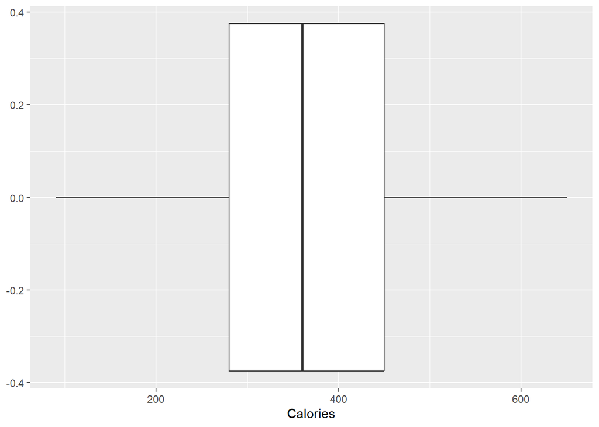

   ```r
   #boxplot of calories column
   calories_plot <- ggplot(starbucks_food, aes(x=Calories)) +
     geom_boxplot()
   calories_plot
   ```

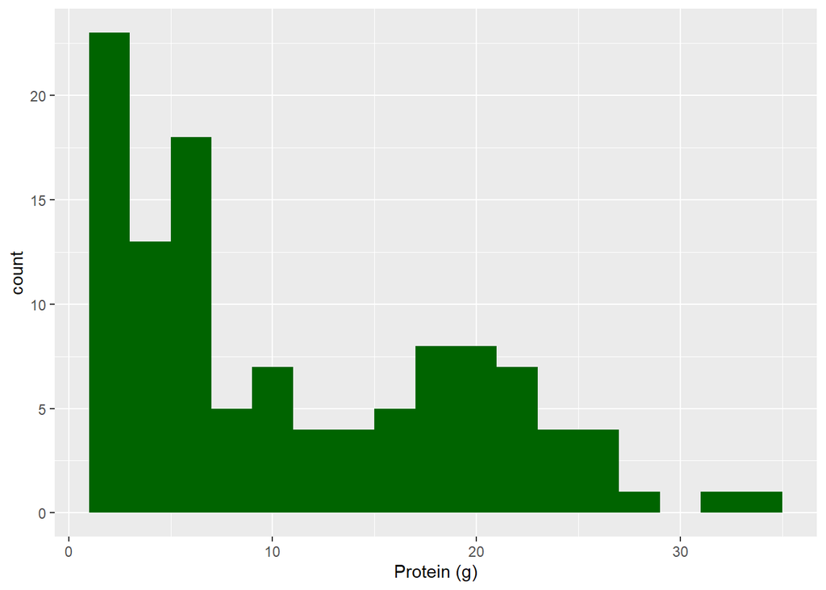

   ```r
   #histogram of protein(g) column with binwidth as 3
   protein_plot <- ggplot(starbucks_food, aes(x=`Protein (g)`)) +
     geom_histogram(fill='darkgreen', binwidth = 2)
   protein_plot
   ```

4. Choose a pair of variables you suspect or hypothesize may be correlated and a graph (scatter plot or barplot) using them. Based on the visual evidence, do you see any potential correlation between the two variables **(10%)**

   Hypothesis: Food items that have more calories have more fat content The hypothesis is true and there is a positive relationship between Calories and fat. Increase in calories, increases the fat content and vice versa.

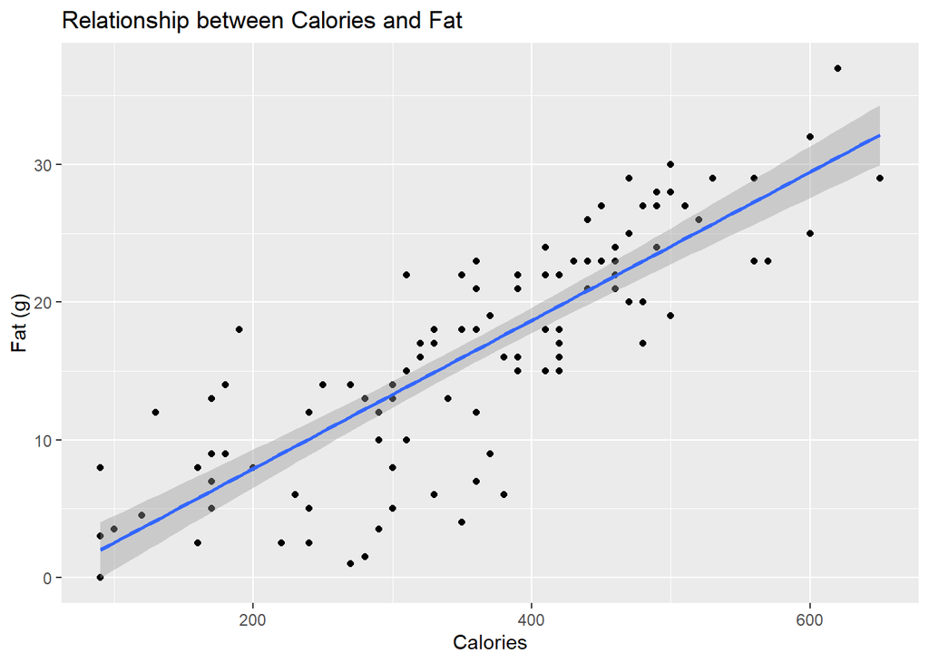

   ```r
   #scatterplot of Calories and Fat (g)
   ggplot(starbucks_food,aes(y=`Fat (g)`, x=Calories)) +
     geom_point() +
     geom_smooth(method = "lm") +
     labs(title = "Relationship between Calories and Fat")
   ```

## Appendix: sources for data to be used in Part 3

**Here are some online sources and popular Online Dataset Hub:**

1. Many US governments (usually at the federal and state levels), bureaus, and departments have open data archives on their websites, allowing the public to access, download, and use them. Just use Google to search for them.
2. [**The Harvard Dataverse Repository**](https://dataverse.harvard.edu/) is a free data repository open to all researchers from any discipline, inside and outside the Harvard community, where you can share, archive, cite, access, and explore research data. Each individual Dataverse collection is a customizable collection of datasets (or a virtual repository) for organizing, managing, and showcasing datasets.
3. [**Inter-university Consortium for Political and Social Research (ICPSR)**](https://www.icpsr.umich.edu/web/pages/ICPSR/index.html) of the University of Michigan-Ann Arbor provides leadership and training in data access, curation, and methods of analysis for the social science research community.
4. **UN: https://data.un.org/**
5. [**OECD Data**](https://data.oecd.org/): economic and development data of the most developed countries in the world.
6. The upper five sources are mainly for social science data; **there is another very big community and open data archives for machine-learning and data science: [Kaggle](https://www.kaggle.com/datasets).**